# vary high risk threshold with multiple marker model

[(<- Back)](http://mdbrown.github.io/summary.html)

## Vary high risk threshold with multiple marker model (N is 250 )

### simulation model

$\begin{aligned} Pr(D = 1) & = \rho\\ Y_\bar D & \sim N( \tilde 0 , \Sigma) \\ Y_D & \sim N( \tilde \mu , \Sigma) \end{aligned}$ which induces a linear logistic model

$Pr(D = 1 | Y) = expit(logit(\rho) + (1/2)((x - \mu)' \Sigma^{-1} (x-\mu) - x' \Sigma^{-1} x))$

Sampling distributions for estimates based on fitted risks using logistic regression were obtained from 5,000 simulations for each $rh$. The sample size was set at $n = 250$.

### True Measure Values

| rho | HR_D | HR_nD | NB | sNB | AUC | MRD | AARD | rh |
| --- | --- | --- | --- | --- | --- | --- | --- | --- |
| 0.1 | 0.58 | 0.42 | 0.02 | 0.15 | 0.61 | 0.01 | 0.15 | 0.1 |
| 0.1 | 0.37 | 0.23 | 0.01 | 0.08 | 0.61 | 0.01 | 0.15 | 0.12 |
| 0.1 | 0.21 | 0.12 | 0 | 0.04 | 0.61 | 0.01 | 0.15 | 0.14 |
| 0.1 | 0.11 | 0.05 | 0 | 0.02 | 0.61 | 0.01 | 0.15 | 0.16 |
| 0.1 | 0.05 | 0.02 | 0 | 0.01 | 0.61 | 0.01 | 0.15 | 0.18 |

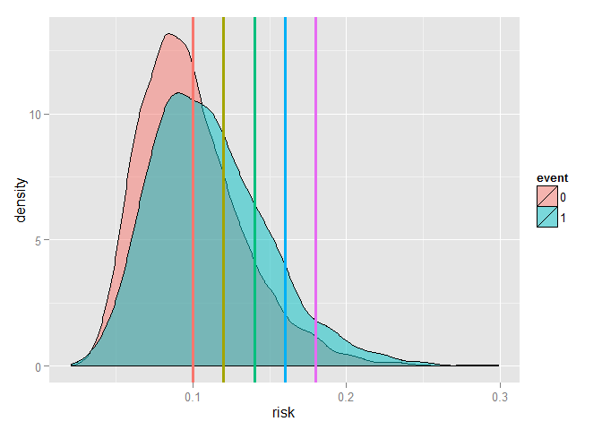

Figure 1: plot of the distribution of risk given event status. Risk thresholds *rh* shown as vertical lines.

## Evaluate a single risk Model

Simulated sampling distributions shown below for all measures evaluting a single risk model . Measures are calculated using both fitted and true risk scores.

**Note the upward/downward bias in the fitted estimates, which is not prevalent in the estimates using true risk. This may indicate overfitting.**

### Measures that depend on $r_H$

#### 1.$HR_D(r_H) = P(risk(X) > r_H | D = 1)$

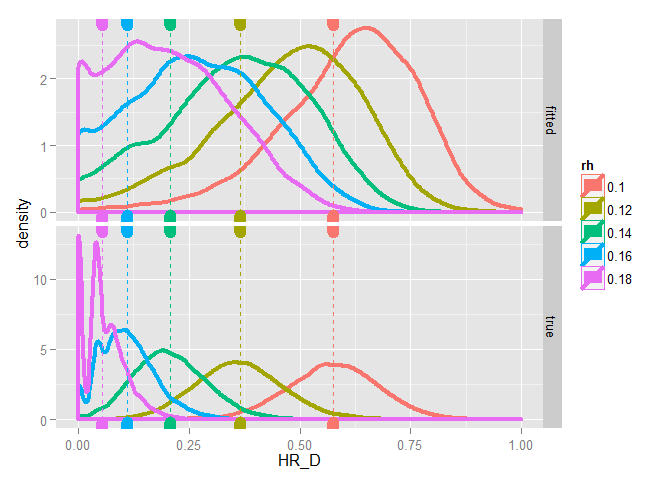

Figure 2: plot of sampling distribution of HR_D(rh) for different values of rh. calculated using 5000 simulations. true values shown by the vertical lines.

#### 2. $HR_{\bar D}(r_H) = P(risk(X) > r_H | D = 0)$

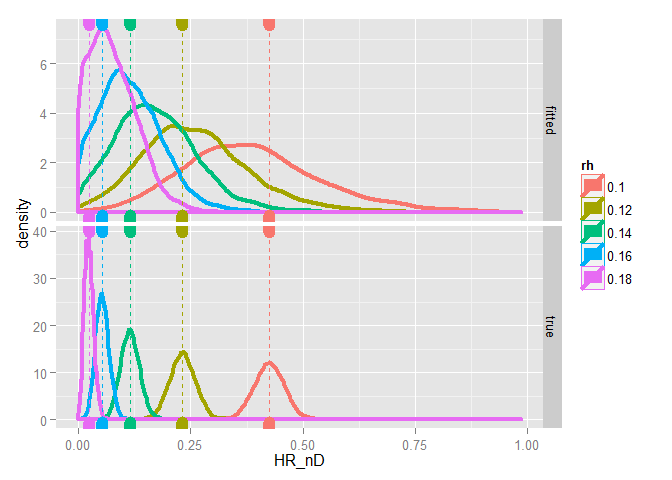

Figure 3: plot of sampling distribution of HR_Dbar(rh) for different values of rh. calculated using 5000 simulations. true values shown by the vertical lines.

#### 3. $NB(r_H) = \rho HR_D(r_H) - (1-\rho)\frac{r_h}{(1-r_H)}HR_{\bar D}(r_H)$

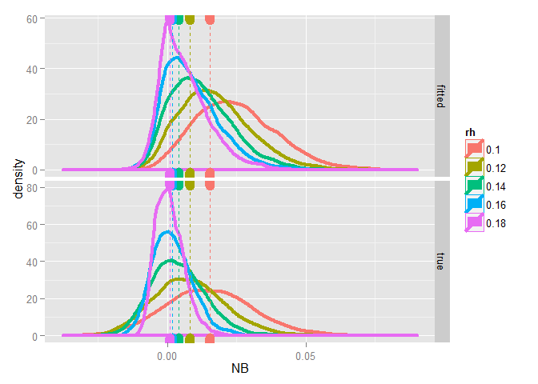

Figure 4: plot of sampling distribution of NB(rh) for different values of rh. true values shown by the vertical lines.

#### 4. $sNB(r_H) = HR_D(r_H) - \frac{(1-\rho)}{\rho} \frac{r_h}{(1-r_H)}HR_{\bar D}(r_H)$

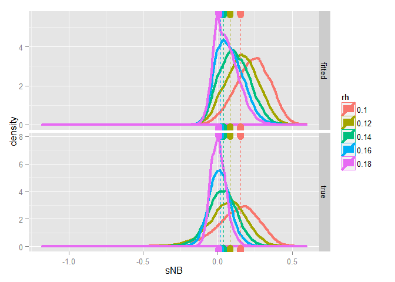

Figure 5: plot of sampling distribution of sNB(rh) for different values of rh. true values shown by the vertical lines.

### Measures that are independ of $r_H$

Here I include sampling distributions for measures based on fitted risk (conditional estimates) and for measures estimating using risks determined by the true model.

#### 5. $AUC = Pr(risk(X_i ) \geq risk(X_j ) | D_i = 1, D_j = 0 )$

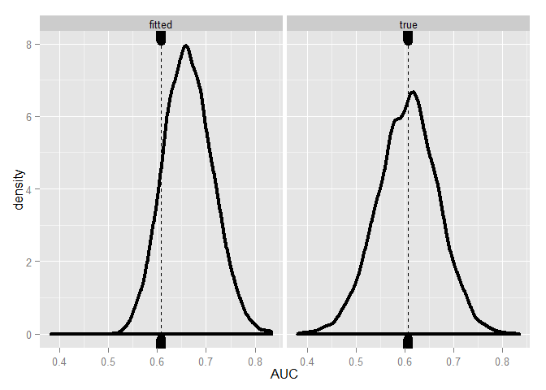

Figure 6: plot of sampling distribution of the AUC for different values of rh. true values shown by the vertical lines.

#### 6. $MRD = E( risk(X) | D = 1) - E( risk(X) | D =0)$

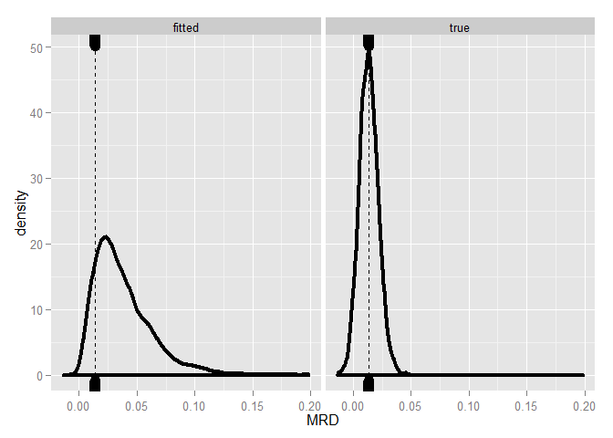

Figure 7: plot of sampling distribution of the MRD for different values of rh. true values shown by the vertical lines.

#### 7. $AARD = Pr(risk(X) > \rho | D = 1) - Pr(risk(X) > \rho | D = 0)$

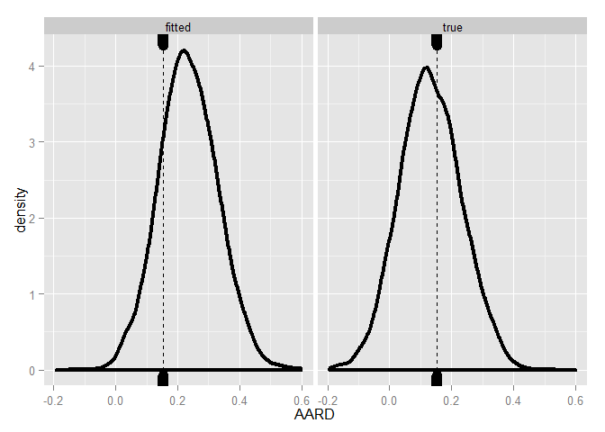

Figure 8: plot of sampling distribution of the AARD for different values of rh. true values shown by the vertical lines.